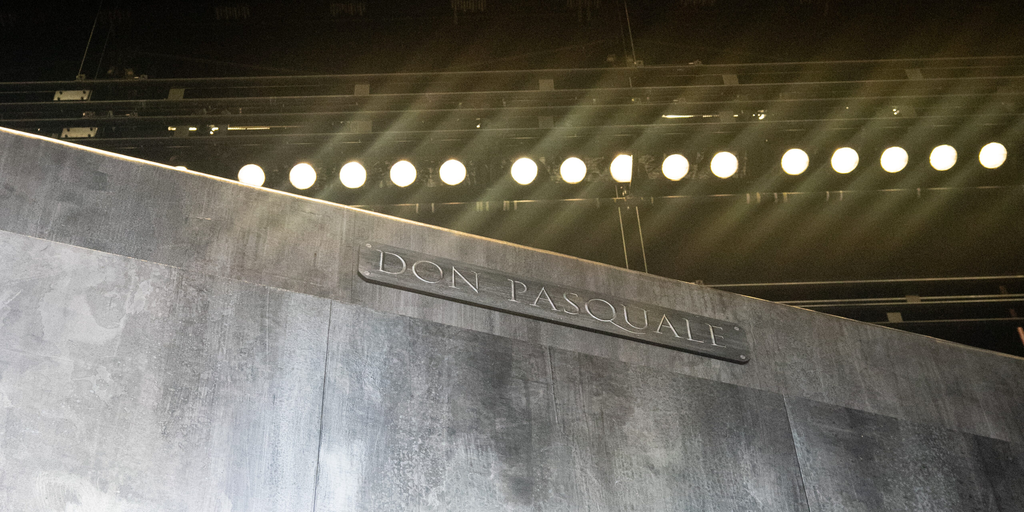

# Der Don Pasquale des Monsieur Donizetti

Veröffentlicht: 9. Juni 2022

Keine Kommentare

Tags: [Don Paquale](https://blog.staatsoper-hamburg.de/tag/don-paquale/), [Donizetti](https://blog.staatsoper-hamburg.de/tag/donizetti/)

Einblicke in das Menschlich-Allzumenschliche. Ein Beitrag von Detlef Giese aus dem Journal Nr. 5 der Spielzeit 2021|22 über einen der wichtigsten Opernkomponisten der Geschichte: Gaetano Donizetti. Außerdem über die Figur Don Pasquale die er vor nun über hundert Jah erschuf.

Schier unglaublich ist die Produktivität, die Gaetano Donizetti an den Tag legte, jener umtriebige, europaweit beschäftigte italienische Opernmeister, der sich von Rossini inspirieren lies und dem Verdi viel verdankt. Die Liste seiner Bühnenwerke ist in der Tat beeindruckend – rund 70 Stücke umfasst sein Œuvre, sowohl im komischen als auch im ernsten Fach, einschließlich so mancher Mischformen. Und wenn man bedenkt, dass diese Menge, ja Unmenge an Noten innerhalb von nur gut zwei Jahrzehnten, von den zögernden Anfängen um 1820 bis zu den reifen Werken der frühen 1840er Jahren entstanden ist, so gerät man durchaus ins Staunen über diese Fleisarbeit.  
Dabei haben die sogenannten „Vielschreiber“, zu denen Donizetti zweifellos zu zählen ist, keinen sonderlich guten Ruf. Ein Werk nach dem anderen zu produzieren, fast immer in Eile und vermeintlich nur wenig sorgfältig, führt fast zwangsläufig zu der Einschätzung, oberflächlich statt tiefgründig zu sein und das Geschäftliche vor die Kunst zu stellen. Die Rastlosigkeit, mit der Donizetti eine Oper nach der anderen komponierte, dabei wiederholt auch auf ältere Entwurfe zurückgriff und einen beständigen Prozess von Umformung und Neufassung in Gang setzte, ist aber keineswegs nur aus seiner persönlichen Disposition heraus zu erklären, sondern liegt in den speziellen Bedingungen des kommerziellen Theaterbetriebs begründet. Das Publikum – und mit ihm die Opernhäuser und ihre mächtigen Impresarios – verlangten nach immer neuen Stoffen und Werken; solange sie Erfolg hatten, blieben sie auf den Spielplänen, um im Falle des Nachlassens der Resonanz dann ohne Umschweife von nachfolgenden Stücken ersetzt zu werden. Die Komponisten hatten sich diesem System zu beugen, wollten sie in der Opernöffentlichkeit weiter präsent sein – und idealerweise sogar Berühmtheit erlangen, gekoppelt mit wirtschaftlichem Erfolg.

[figure not shown]

Donizetti war gleichsam ein Meister darin, eine derartige Künstlerexistenz zu führen. Virtuos spielte er auf der Klaviatur der Chancen und Möglichkeiten, die ihm das europäische Opernleben bot, ob nun in seiner italienischen Heimat, in Wien oder in Paris. Die französische Musikmetropole, wo bereits sein italienischer Kollege Rossini zu reüssieren wusste, war auch für Donizetti ein attraktiver Ort, sich und seine Kunst zu beweisen. Es spricht für sein Engagement, auch für seine Geschäftstüchtigkeit, dass es ihm Ende der 1830er/Anfang der 1840er Jahre gelang, Auftrage für gleich vier Pariser Opernhäuser zu erhalten, für Bühnen von je individueller ästhetischer Ausrichtung und durchaus unterschiedlichen Erwartungshaltungen von Seiten ihres Leitungspersonals wie ihres Publikums. Die ersten Verbindungen nach Paris hatte Donizetti über das Theatre-Italien geknüpft, in dem Opernwerke in italienischer Sprache zur Aufführung kamen. Als er im Herbst 1838 dort eintraf, stieg sein Stern sofort auf, wesentlich durch den Triumph von Lucia di Lammermoor, aber auch durch die ausgesprochen positive Aufnahme von Roberto Devereux und L’elisir d’amore. An der Opera-Comique, für franzosische Stücke mit gesprochenen Dialogen in eher einfacher Machart reserviert, konnte er mit La fille du régiment einen herausragenden Erfolg verbuchen, während es ihm am Theatre de la Renaissance, einer komplett von Privatmäzenen unterhaltenen Bühne, nicht möglich war, sich als Opernkomponist vorzustellen: Noch bevor L’ange de Nisida in Szene gehen konnte, musste das Unternehmen Bankrott anmelden. Dieses Werk fand jedoch unter einem neuen Titel, La favorite, den Weg in das Repertoire, und zwar an der renommiertesten Aufführungsstätte, der Academie royale de musique, der legendären Opera. Diesem Haus galt Donizettis besonderer Ehrgeiz, bedeutete ein dortiger Erfolg doch, an der Spitze der Karriereleiter angelangt zu sein. Traf seine erste dort präsentierte tragische Oper Le martyrs (eine umgearbeitete und erweiterte Fassung seines neapolitanischen Poliuto) noch nicht auf sonderlich großen Beifall, so änderte sich das mit La favorite spurbar: Das im Stil einer „Grand Opera“ konzipierte Werk entwickelte sich zu einem wahren „Dauerbrenner“ im Repertoire der größten und bedeutsamsten Pariser Musiktheaterbühne. Einem noch ambitionierteren Werk für die Opera, der im Spätherbst des Jahres 1843 entstandenen, zugleich letzten von ihm vollendeten Oper Dom Sébastien, roi de Portugal, war indes nicht das gleiche Glück beschieden: Trotz des hohen personellen Aufwandes von Soli, Chor und Orchester, dazu einer riesigen Komparserie und einer bis dato kaum gekannten Prachtausstattung fand der Sébastien nur wenige Anhänger.

Anders sah es mit einem Werk aus, das Donizettis Popularität neu belebte. In den ersten Tagen des Jahres 1843 war im Theatre- Italien, seiner eigentlichen Erfolgsbühne in Paris, ein Stück vorgestellt worden, das seither immer zu seinen inspiriertesten Schöpfungen gezahlt wurde. War Lucia di Lammermoor Donizettis Meisterwerk im Reich der großen tragischen Oper, so war es das neue Werk auf dem Feld der musikalischen Komödie. Mit Don Pasquale hat sich Donizetti in besonderer Weise in die europäische Musikgeschichte eingeschrieben, als ein Komponist, der hochsensibel das Menschlich-Allzumenschliche auf die Opernbühne gebracht hat, in einer zutiefst humanen Art und Weise, die niemanden der ins Spiel gebrachten Personen desavouiert und doch das der Geschichte innewohnende komödiantische Potential voll erschließt.

„Sprecht, ich bin nur  
noch zwei Ohren,  
selig, stumm, ein Bild  
von Stein.“

PASQUALE, Don Pasquale

In seinem Don Pasquale hat Donizetti verschiedene Traditionsstränge aufgenommen, sie zugleich aber so weitergesponnen, dass nicht nur seine Gegenwart daran Gefallen fand, sondern auch Anknüpfungen gut möglich wurden. Wenn man Vorbilder benennen möchte, so sind dies gewiss Mozarts Le Nozze di Figaro und Rossinis Il barbiere di Siviglia, die nicht umsonst als Musterbeispiele der Opera buffa gelten. Rund ein halbes Jahrhundert nach Donizetti griff Verdi dann in seinem Falstaff nach den Faden, während im 20. Jahrhundert Don Pasquale eine Nachblute in Strauss’ Der Rosenkavalier fand, mehr noch in dessen Die schweigsame Frau, mit so manchen Parallelen in den inhaltlichen Motiven, der Handlungsführung und Personenkonstellation. Donizetti hatte die bewahrte Commedia dell’Arte wieder aktiviert, mit deren Versatzstücken er mit offenkundigem Interesse, großer Erfindungsgabe und entsprechendem Einfallsreichtum brillant zu spielen wusste.  
Entscheidend ist dabei vor allem, dass sämtliche Figuren in diesem Kammerspiel abseits von typisierenden Überzeichnungen eine durch und durch menschliche Physiognomie gewinnen, einschließlich von inneren Wandlungen und Widersprüchen. Donizettis eigene Gegenwart spiegelt sich darin, nicht zuletzt auch mit einer Portion Gesellschaftskritik. Eine bürgerliche Welt wird gezeigt, in der prinzipiell feste Platze zugewiesen sind, in der sich aber immer wieder auch Freiräume zum individuellen Denken und Handeln eröffnen. Elemente von Lustspiel und Schwank sind unverkennbar, zugleich aber auch das Bestreben, Emotionen verschiedenster Art Raum zu geben, abseits von Stereotypen jeglicher Art. Auch wenn nur vier Figuren auftreten (allen anderen, auch dem Chor, sind lediglich Nebenrollen zugewiesen), ist das Spektrum an Aktion und Ausdruck erstaunlich groß. Die auf der Bühne dargestellten Handlungsweisen sind jederzeit „realistisch“ und logisch aus den Figuren selbst heraus begründbar, da an ein Eingreifen von höheren Instanzen im Sinne des „Wunderbaren“ nicht gedacht ist – das wäre mit der Grundanlage des Stückes auch kaum vereinbar gewesen. Vielmehr ist das Werk ganz auf das Hier und Jetzt gestellt, mit Handlungsträgern, die zur Identifizierung einladen. Man erkennt zwar die Urbilder dieser kunstvoll ausgestalteten Charaktere (der hinters Licht geführte dummkluge Alte mit Hagestolzgestus, die kapriziöse, im Grunde wesensgute, aber durchaus auch einmal die Krallen ausfahrende junge Frau, der mit allen Wassern gewaschene zwielichtige Intrigant sowie der schwärmerische, leicht melancholisch angehauchte Liebhaber), sie werden jedoch im Spiel und durch die Musik verwandelt, als seien sie Menschen von Fleisch und Blut.

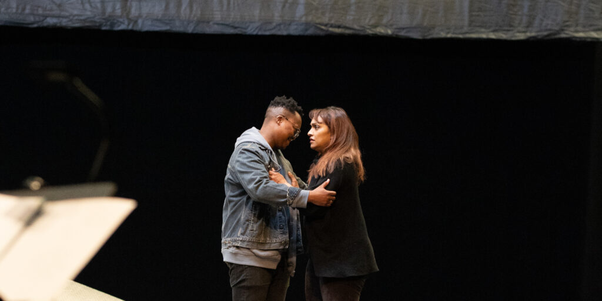

Levy Sekgapane und Danielle De Niese bei den Proben zu Hamburgs „Don Pasquale“

Kaum jemals sonst in seinem überreichen Schaffen hat Donizetti so inspiriert seine Bühnenfiguren musikalisch entwickelt wie im Don Pasquale. Hinsichtlich der Melodieführungen beschwört er vielfach Mozart und dessen Zeitgenossen, mit eminenten kantablen Qualitäten und spurbarem Wohllaut. Seinen Sängerinnen und Sangern, mit denen er am Theatre-Italien zusammenarbeitete, hat er virtuose Partien zugedacht, ohne dass es aber auf die Demonstration bloßer stimmtechnischer Fähigkeiten hinausliefe – immer dienen die Gesangslinien dem Ausdruck des individuellen Ich und sind unmittelbar auf die Szene bezogen. Der Aufbau des Stückes mag insgesamt womöglich ein wenig konventionell wirken, die Binnengestaltung der Arien, Duette und Ensembles ist es keineswegs. Donizetti verstand es, überraschende Momente und sprichwörtliche „Pointen“ stets mit einzukomponieren – originelle harmonische Ausweichungen, rhythmische „Störungen“ oder auch melodische Wendungen, die so nicht zu erwarten sind. Diese ausgesprochene Vielschichtigkeit ist es, wodurch Donizettis letzte, subtil und geistreich mit Operntraditionen spielende Buffa ihren Reiz gewinnt, wodurch die Aufmerksamkeit gefesselt wird und wodurch sowohl das breite Publikum als auch die ausgewiesenen „Kenner“ angesprochen werden.

Eine enorme gestische Präsenz ist der Musik eigen. Sie spricht aus sich selbst heraus, indem sie Ausdruckscharaktere in sich trägt, die ganz unmittelbar auf die Figur und ihre jeweiligen Gefühlszustande verweisen. Wenngleich der Komödienton aus naheliegenden Gründen vorherrschend ist, so gibt es wiederholt doch auch Passagen, die geradezu tragische Größe besitzen, und die nicht etwa als „gespielt“ oder ironisch erscheinen, sondern als offen, ehrlich und authentisch empfunden werden – auch das macht Donizettis Don Pasquale so interessant, nahezu einzigartig. Das Werk ist also nicht nur ein Stück mit Buffa-Charakter – wenngleich dieser nicht zu verkennen ist –, sondern besitzt auch noch weitere Dimensionen, die durch eine überlegte musikalische wie szenische Ausgestaltung ans Licht kommen können. So sehr Donizetti in seinem Don Pasquale auch den Geist der alten Buffa beschwort, so sehr gibt er doch auch einem tiefen Ernst Raum zur Entfaltung, zumindest aber dem Tragikomischen. Ohne diese Wesenszüge wäre das Werk sicher nicht begriffen, ohne sie würde es nicht denselben Reichtum offenbaren, den es zweifellos besitzt. Und ohne dieses Changieren zwischen den Gegensätzen hatte die Oper sicher auch nicht das starke internationale Echo gefunden, bei den Zeitgenossen wie bei der Nachwelt. Anspruchsvolle Unterhaltung wurde ihnen durch diese raffiniert gestaltete, temporeiche, vielschichtige Komödie geboten, darüber hinaus auch Tiefgang und Nachdenklichkeit, mit diversen Deutungsmöglichkeiten. Eine musikalische Komödie mit menschlich-allzumenschlichen Höhen und Tiefen begegnet uns im Don Pasquale des Monsieur Donizetti, der für wenige Jahre kometenhaft am Pariser Opernhimmel erschienen war, als ob er in seiner Oper einer Weisheit aus Lessings Minna von Barnhelm Ausdruck geben wollte: „Was haben Sie denn gegen das Lachen? Kann man denn auch nicht lachend sehr ernsthaft sein?“

Teilen

## Don Pasquale

Ein älterer Herr, schrullig, wohlhabend und bereit für eine letzte lustvolle Liebe, dazu ein junges Paar, dem Geldnot auf dem Weg zum Liebesglück im Weg steht, und ein befreundeter Arzt, der die perfekte Intrige parat hat, um die individuellen Wünsche in einer Dreieckskonstellation in die Luft gehen zu lassen. Die vier Figuren scheinen frisch der Commedia dell’arte entsprungen und doch stehen sie als Menschen da: verletzlich, angreifbar und voller unvereinbarer Sehnsüchte. Wenn der alte reiche Mann die junge schöne Frau will, die junge schöne Frau aber lieber den reizenden jungen Mann – das Geld aber irgendwie auch … ja, dann sind wir mittendrin im unwiderstehlichen Sog einer Opera buffa, die das Lachen über alle Schmerzgrenzen hinweg feiert. Ein böses Spiel und doch so wunderbar.

[Mehr…](https://www.staatsoper-hamburg.de/de/spielplan/stueck.php?AuffNr=182497)

[Voriger Beitrag](https://blog.staatsoper-hamburg.de/auf-einen-schnack-mit-ailyn-perez/)

[Auf einen Schnack mit: Ailyn Pérez](https://blog.staatsoper-hamburg.de/auf-einen-schnack-mit-ailyn-perez/)

[Nächster Beitrag](https://blog.staatsoper-hamburg.de/podcast-videodesigner-jonas-link-ueber-die-urauffuehrung-la-luna/)

[Podcast: Videodesigner Jonas Link über die Uraufführung La Luna](https://blog.staatsoper-hamburg.de/podcast-videodesigner-jonas-link-ueber-die-urauffuehrung-la-luna/)

[interactive chart not shown]